# Who Heard the Alarm?

Module 8 · ARDL, information, and exogeneity

Gary Cornwall

Econ 6376 · The George Washington University

# Act I · Letting another variable into the room

One series’ memory becomes a relationship across series.

## ARMA: one series remembers outcomes and surprises

$$y_t=\alpha+\phi_1y_{t-1}+\theta_1\epsilon_{t-1}+\epsilon_t$$

[figure not shown]

A time-unrolled DAG: each date is a different node. Innovations ε are unobserved DGP quantities.

## ARDL: another series brings its own history

$$y_t=\alpha+\phi_1y_{t-1}+\beta_0x_t+\beta_1x_{t-1}+\epsilon_t$$

[figure not shown]

Observed x replaces the explicit MA block. Drawing an arrow does not identify a causal effect.

## Where we are: expand the mixing board

$$y_t=\alpha+\delta t+\sum_{j=1}^{p}\phi_jy_{t-j}
+\sum_{\ell=1}^{q}\theta_\ell\epsilon_{t-\ell}+\epsilon_t$$

| Channel | Module 8 baseline |
| --- | --- |
| Intercept and outcome memory | **On**: $\alpha$, $\phi_jy_{t-j}$ |
| Trend and explicit MA memory | **Off** |
| Observed predictor history | **New**: $\sum_{\ell=0}^{q}\beta_\ell x_{t-\ell}$ |
| Current disturbance | Still present; its relation to $x$ now matters |

Module 7 combined forecasts. Today we add information absent from that forecast pool.

## One conditional equation, many possible lags

$$y_t=\alpha+\sum_{j=1}^{p}\phi_jy_{t-j}
+\sum_{\ell=0}^{q}\beta_\ell x_{t-\ell}+\epsilon_t$$

| Restriction | Model left on the board |
| --- | --- |
| All $\beta_\ell=0$ | AR$(p)$ |
| All $\phi_j=0$ | Distributed-lag regression |
| $q=0$ | Outcome lags **and current $x$** |
| $\beta_0=0$ | Lag-only predictor block |

What does ARDL(1,2) include that ARDL(1,1) does not?

Here q means the maximum x lag. It is not the MA order.

## The DGP and our fitted equation remain different

**DGP: parameters and disturbances we know only in a simulation**

$$y_t=\alpha+\phi_1y_{t-1}+\beta_0x_t+\beta_1x_{t-1}+\epsilon_t$$

**Estimated equation: hats and an observed residual**

$$y_t=\hat\alpha+\hat\phi_1y_{t-1}+\hat\beta_0x_t+\hat\beta_1x_{t-1}+e_t$$

$$e_t=y_t-\hat y_t$$

Fitted values: ŷ. Forecasts from Module 7 onward: $\tilde y_{t+h\mid t}$.

## Keep the stationary baseline visible

$$\Phi(L)=1-\phi_1L-\cdots-\phi_pL^p$$

Stationary inputs + stable dynamics + suitable disturbances.

- AR lag-polynomial roots lie **outside** the unit circle.
- For one outcome lag: $|\phi_1|<1$.
- If $x$ responds to past $y$, check stability of the **joint system**.

Trending levels need additional reasoning. Cointegration is a later route, not a blanket exemption.

# Act II · Who else heard the news?

Exogeneity is the central question.

## The Office: everyone reacts to the same emergency

If claims and unemployment rise in the same month, which story has the regression established?

Optional clip: [The Office · Fire Drill (official)](https://www.youtube.com/watch?v=gO8N3L_aERg). The diagram remains usable offline.

## Exogeneity asks what remains in the disturbance

Let $\mathcal F_{t-1}$ contain the relevant histories of $y$ and $x$.

$$\boxed{E[\epsilon_t\mid\mathcal F_{t-1},x_t]=0}$$

After using the modeled history and current x, no predictable mean component remains.

- This covers **all included regressors**, including lagged $y$.
- With stability, moments, and adequate regressor variation, it supports **large-sample OLS consistency**.
- It does not promise exact recovery in one finite sample.

## Three claims that sound similar

**x and y are related**Often why we included x. This is not the exogeneity restriction.

**ε has no serial correlation**A statement about the disturbance across dates.

**$E[\epsilon_t\mid\mathcal F_{t-1},x_t]=0$**A statement about the disturbance relative to the regressor information.

Could two white-noise shocks be correlated with each other today?

Yes. No memory is not independence from every other process.

## Common current news creates an omitted route

If the outcome disturbance contains shared news, current x may reveal part of that disturbance.

## Lagged feedback is a different issue

$$x_t=0.5x_{t-1}+0.2y_{t-1}+\epsilon_{x,t}$$

With independent current shocks, independent of the past, this feedback can coexist with our conditional-mean restriction.

## Stronger assumptions and narrower diagnostics

**Strict exogeneity** asks today’s disturbance to be unrelated to the entire $x$ path—including future $x$.

Lagged feedback may violate that stronger requirement while the sequential conditional mean remains valid.

| Proposed fix | What it cannot establish |
| --- | --- |
| “Use a lag” | Earlier does not guarantee exogenous |
| “The residual ACF looks clean” | No proof of structural exogeneity |
| “Use HAC standard errors” | No repair for invalid coefficient moments |

Are we making a prediction claim, a conditional-path claim, or a causal claim?

# Act III · Build it, then break it

Same structural coefficients. Different information.

## Two equations we control

$$\begin{aligned}
x_t&=0.5x_{t-1}+c\,y_{t-1}+\epsilon_{x,t},\\
y_t&=0.2+0.6y_{t-1}+0.4x_t+0.2x_{t-1}+\epsilon_t.
\end{aligned}$$

Current shocks have variance one and correlation $r$. Shock pairs are independent across dates.

| Case | Feedback $c$ | Shock correlation $r$ |
| --- | --- | --- |
| Baseline | 0 | 0 |
| Shared current shocks | 0 | 0.7 |
| Lagged feedback only | 0.2 | 0 |

## Live code: the for-loop is the model

LIVE CODE · build, fit, then change one assumption

```r
# Excerpt from ardl_simulator(); initialization is in the full helper.
epsilon_x <- rnorm(total)
epsilon <- shock_corr * epsilon_x +
  sqrt(1 - shock_corr^2) * rnorm(total)
for (t in 2:total) {
  x[t] <- 0.5*x[t-1] + feedback*y[t-1] + epsilon_x[t]
  y[t] <- 0.2 + 0.6*y[t-1] + 0.4*x[t] +
    0.2*x[t-1] + epsilon[t]
}
```

Which change should move OLS away from the structural coefficient 0.4?

## One sample is not the distribution

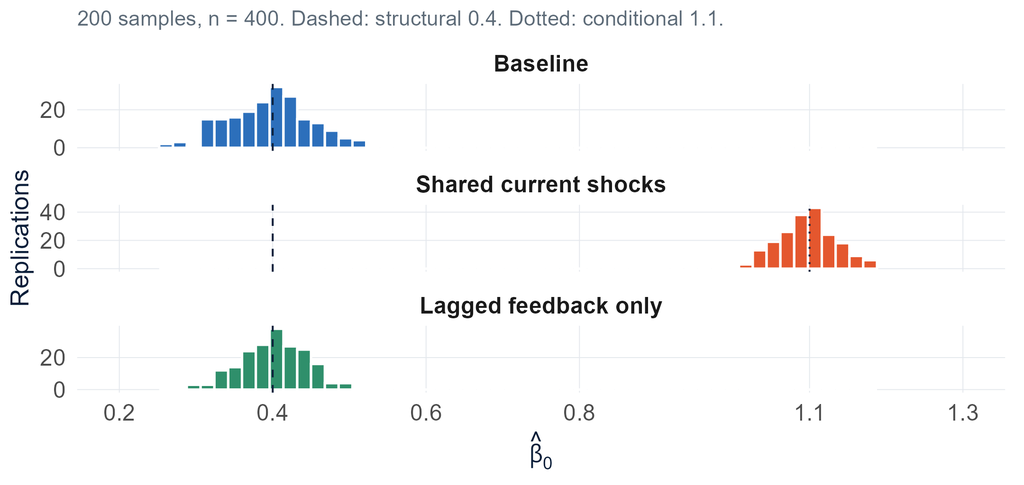

More observations reduce sampling noise. They cannot identify the structural coefficient from an invalid restriction.

## The wrong structural answer can have clean residuals

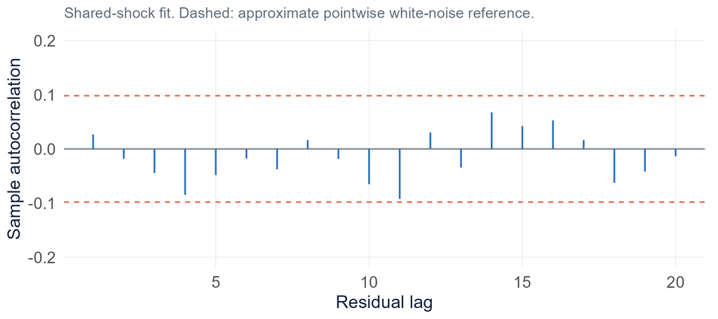

What did the ACF check—and what did it leave unanswered?

## OLS is answering a different conditional question

For the Gaussian shared-shock case,

$$E[\epsilon_t\mid\epsilon_{x,t}]=0.7\epsilon_{x,t},
\qquad \epsilon_{x,t}=x_t-0.5x_{t-1}.$$

Therefore,

$$E[y_t\mid\mathcal F_{t-1},x_t]
=0.2+0.6y_{t-1}+1.1x_t-0.15x_{t-1}.$$

| Coefficient | Structural DGP | Conditional regression |
| --- | --- | --- |
| Current $x$ | 0.4 | 1.1 |
| Lagged $x$ | 0.2 | −0.15 |

A useful conditional predictor need not recover the causal mechanism we wanted.

# Act IV · Follow every path

A coefficient is one route. A response follows all routes.

## First specify the input experiment

$$y_t=0.6y_{t-1}+0.4x_t+0.2x_{t-1}+\epsilon_t$$

| Imposed change in $x$ | Today | Next period | Later |
| --- | --- | --- | --- |
| **Pulse** | +1 | 0 | 0 |
| **Permanent step** | +1 | +1 | +1 |

Hold initial outcome history and outcome shocks fixed; compare the two $y$ paths.

Should a one-period pulse and a permanent step have the same long-run response?

## Tomorrow has two routes from today’s x

$$m_0=\beta_0=0.4$$

$$m_1=\underbrace{0.6(0.4)}_{\text{inherited}}+\underbrace{0.2}_{\text{direct}}=0.44$$

β₁ alone is not the total next-period response.

## Pulse decays; repeated pulses accumulate

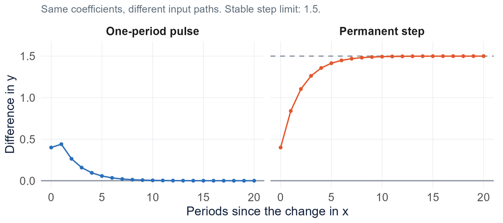

$$m_2=0.264,\qquad \text{step at }h=2=0.4+0.44+0.264=1.104.$$

## The long-run multiplier needs stability

$$\text{Long-run step multiplier}
=\frac{\sum_{\ell=0}^{q}\beta_\ell}{1-\sum_{j=1}^{p}\phi_j}$$

$$\frac{0.4+0.2}{1-0.6}=1.5$$

- A permanent +1 in $x$ eventually changes $y$ by **+1.5**.
- The one-period pulse itself converges to **zero**.
- Estimated multipliers carry hats; a denominator near zero makes estimates sensitive.

If φ₁ = 1.05, does the nonzero denominator make −12 an eventual response?

## Break it: a finite ratio can describe no limit

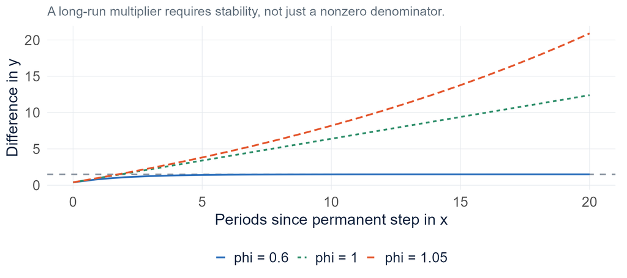

At φ₁ = 1.05 the path grows. The algebraic ratio −12 is not its limit.

## An x innovation can create a whole input path

In the independent-shock, no-feedback baseline,

$$x_t=0.5x_{t-1}+\epsilon_{x,t}.$$

A unit innovation creates an **x-path deviation** of $(1,0.5,0.25,\ldots)$, not an imposed pulse.

$$\text{Outcome response at }h=1=0.44+0.4(0.5)=0.64.$$

Conditional path response, response to an innovation, and causal intervention are distinct objects.

What else must be followed if x responds to past y?

# Act V · A predictor needs a calendar

Initial claims and unemployment, with an honest forecast origin.

## The familiar workflow gets two new questions

**Inspect → specify**Units, transformations, lag lengths, release dates.

**Estimate → diagnose**Common estimation sample; residual plots and regression diagnostics.

**Revise → evaluate**Training-only choices; identical holdout dates and benchmarks.

When was x available?  
What interpretation do the assumptions support?

## A future outcome may need a future predictor

$$\tilde y_{t+1\mid t}=\hat\alpha+\hat\phi_1y_t
+\hat\beta_0\tilde x_{t+1\mid t}+\hat\beta_1x_t$$

| Information about future $x$ | Claim we can make |
| --- | --- |
| Forecast from its own model | Forecast with predictor uncertainty |
| Stipulated path | Conditional / scenario forecast |
| Released before the target outcome | Nowcast using that information |

If an evaluation substitutes the future realized x, what advantage has it given the model?

## Reference month is not release date

One step ahead in the monthly index; usually a nowcast of the current calendar month.

Schematic timing, not an exact historical release calendar. Use $\mathcal I_t^{\mathrm{release}}$ for this origin.

## What are we actually modeling?

$$y_t=\Delta U_t,\qquad x_t=100\Delta\log C_t$$

**U: unemployment rate**Monthly percent. y is its change in percentage points.

**C: initial claims**Mean of weekly counts whose week-ending Saturdays fall in the month.

**x: claims growth**100 × log change, approximately percent growth in that monthly mean.

A monthly mean of weekly claims is not a monthly total.

## Inspect the transformed training data

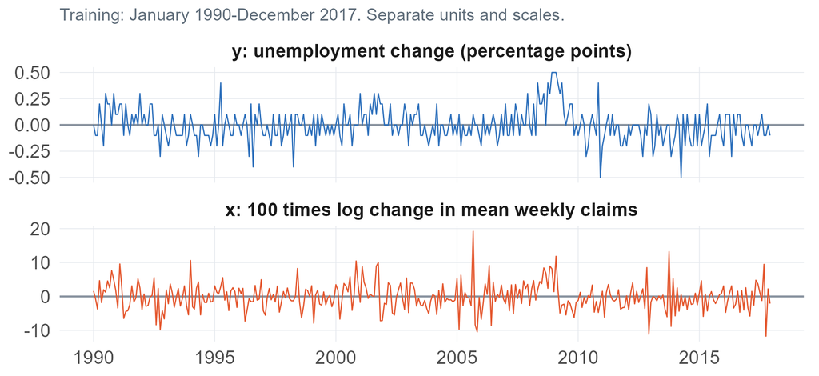

1990–2017 only. ADF rejects a unit root; KPSS does not reject level stationarity for either transformation at 5%.

## Fit on a common sample; keep the holdout untouched

$$y_t=\alpha+\sum_{j=1}^{p}\phi_jy_{t-j}
+\sum_{\ell=1}^{q}\beta_\ell x_{t-\ell}+\epsilon_t$$

**TRAIN · Jan 1990–Dec 2017**336 common rows · choose by BIC

**HOLDOUT**2018–2019 · 24 rows

**Lag-only claims:** $\beta_0=0$. No complete target-month claims average required.

**First menu:** $p=1,2,3$; add one to three claims lags. Compare with AR benchmarks.

Does using yesterday’s claims prove that omitted labor-market news is irrelevant?

## Diagnose, revise once, and report what remains

| Training decision | What happened |
| --- | --- |
| Small menu | AR(3) and lag-only ARDL(3,3) selected |
| Residual serial-correlation check | BG(12) $p\approx0.0000085$ |
| One justified expansion | Up to 12 outcome lags for **both** families |
| Revised selection | AR(6), lag-only ARDL(6,3) |
| Revised diagnostics | Stable AR roots; BG(12) $p\approx0.0031$ |

Residual dependence remains. Stop this illustration and disclose it; do not search until the diagnostic passes.

## Roll the information, keep the coefficients fixed

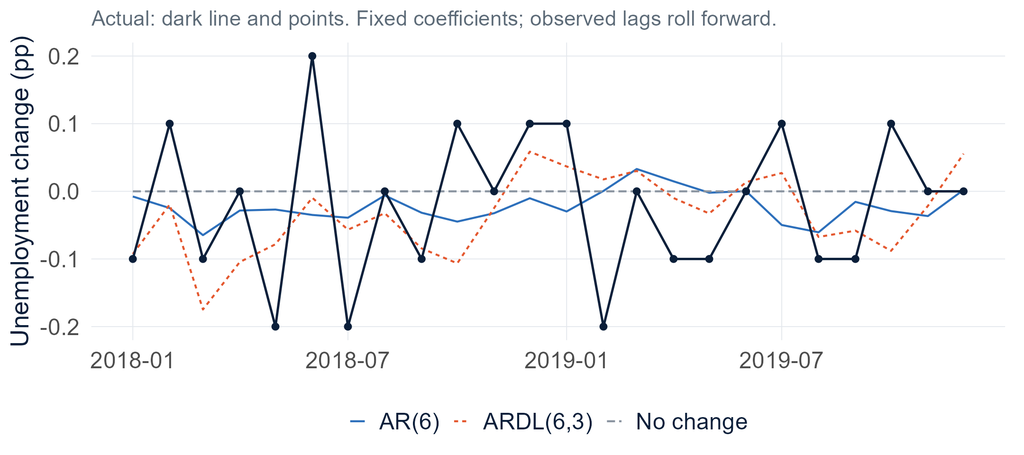

Observed lags update after release. Coefficients remain estimated on 1990–2017. No-change predicts ΔU = 0.

## The claims model improves this score—not every claim

| Model | RMSE | MAE |
| --- | --- | --- |
| AR(6) | 0.1129 | 0.0929 |
| Lag-only ARDL(6,3) | **0.1057** | **0.0831** |
| No change in unemployment | 0.1099 | 0.0875 |

Unemployment percentage points · identical 24 dates · revised-data pseudo-out-of-sample evaluation.

Which statement is supported: “claims helped this forecast” or “raising claims causes unemployment to rise”?

A short-window ranking is descriptive evidence. Residual dependence and real-time-vintage limitations remain.

# Act VI · Three doors out of ARDL

Brief orientation to the next modules.

## Looking Ahead: does x’s past add predictive information?

MODULE 9 · GRANGER CAUSALITY · OPTIONAL PREVIEW

For a **lag-only** linear model and a stated conditioning set,

$$H_0:\beta_1=\beta_2=\cdots=\beta_q=0.$$

**A joint question:** do these $x$ lags add information beyond the history already included?

Predictive precedence can arise from an early signal of a common driver. It does not identify an intervention effect.

Would adding another predictor potentially change this answer?

## Looking Ahead: can wandering levels share a stable gap?

MODULE 10 · COINTEGRATION · OPTIONAL PREVIEW

$$y_t\sim I(1),\qquad x_t\sim I(1),\qquad y_t-a-bx_t\sim I(0).$$

**Harry and his dog, Mouse:** both wander, but their separation can remain stationary.

- Cointegration concerns a **stationary combination** of nonstationary levels.
- An error-correction model links short-run changes to last period’s deviation.
- Rewriting an ARDL as an ECM is **algebra, not a cointegration test**.

What would differ if they wandered independently with no stable separation?

## Looking Ahead: give every variable an equation

MODULES 11–12 · VAR AND SHOCK INTERPRETATION

$$\begin{aligned}
y_t&=a_y+b_{yy}y_{t-1}+b_{yx}x_{t-1}+\epsilon_{y,t},\\
x_t&=a_x+b_{xy}y_{t-1}+b_{xx}x_{t-1}+\epsilon_{x,t}.
\end{aligned}$$

**The ensemble cast:** both histories can help explain both outcomes.

A system models joint evolution and forecast feedback. It still needs assumptions to identify causal shocks.

## Key takeaways + next time

**ARDL adds observed predictor history to outcome memory.**

**Exogeneity concerns the disturbance and the whole information set.**

**A response follows every path; state the input experiment first.**

**A forecast needs an honest calendar and a common benchmark.**

Next: does one variable’s past improve prediction beyond the information already being used?

Depth and runnable code: Module 8 notes §§8.1–8.7. Enders ch. 5 §2; Hamilton §8.2. Optional previews: Modules 9–10.